# PSI - Wonderful-Wednesdays

November-2025 Visualization Challenge - Scroll Story

# Bad Visualizations Challenge

Scroll to explore common visualization pitfalls and their solutions

**Welcome to the visualization challenge!** This interactive story walks through 5 common mistakes in pharmaceutical data visualization. As you scroll, you'll see problematic charts on the left, understand what's wrong, and discover improved versions on the right.

Each challenge demonstrates real-world visualization pitfalls that can mislead decision-makers. Let's dive in...

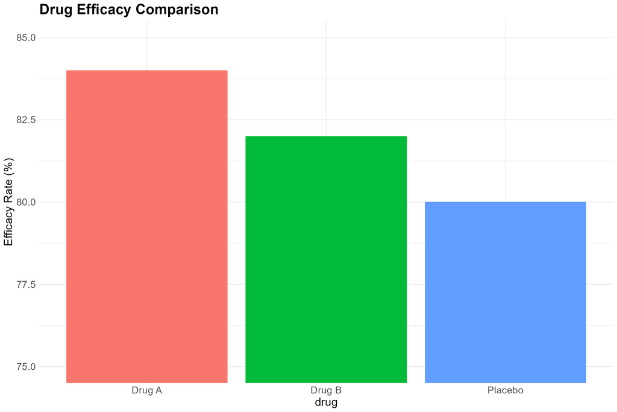

Problematic

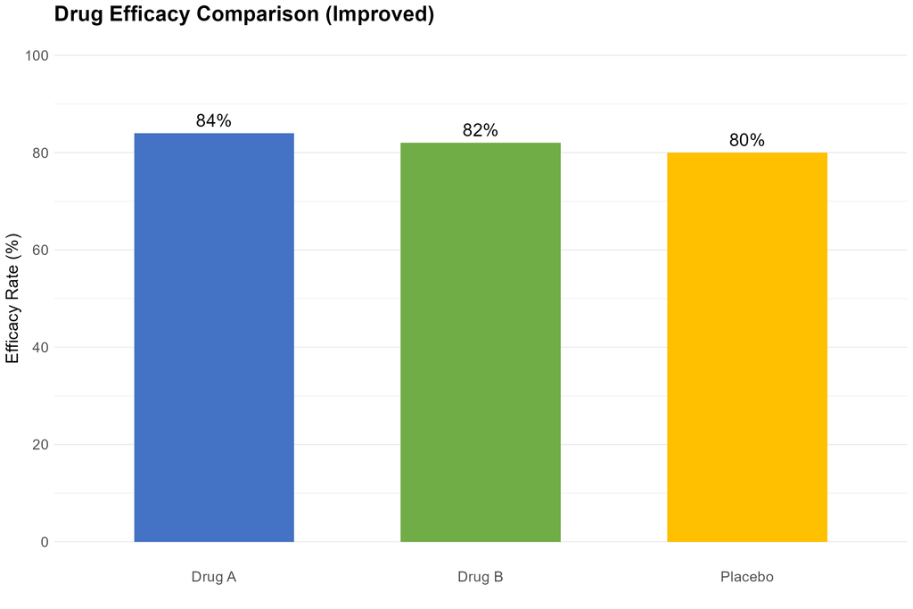

Improved

### Challenge 1: Drug Efficacy

This chart compares efficacy rates for Drug A, Drug B, and Placebo from a Phase III clinical trial.

At first glance, Drug A appears dramatically more effective than the others. But is it really?

**❌ The Problem:**

The y-axis is truncated (75-85%), which exaggerates small differences. The actual difference between Drug A (84%) and Placebo (80%) is only 4 percentage points.

**✓ The Solution:**

- Y-axis starts at 0% for accurate visual comparison
- Added value labels for precise readings
- Consistent, professional color scheme

Now the true scale of differences is clear.

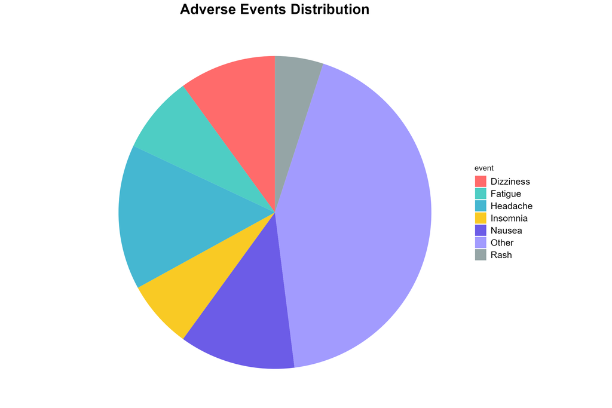

Problematic

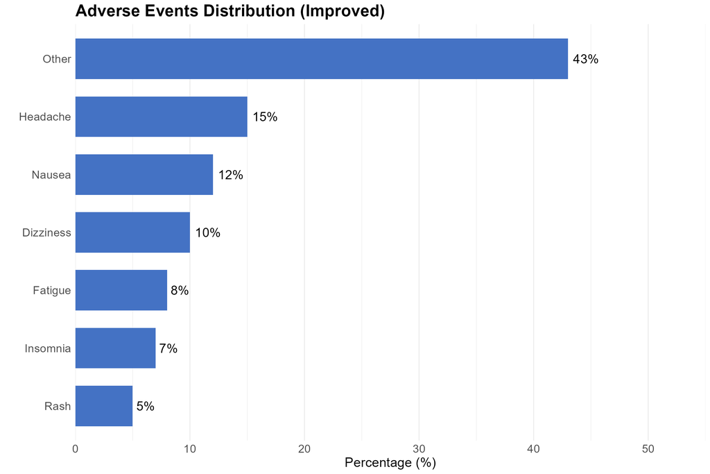

Improved

### Challenge 2: Adverse Events

This pie chart shows the distribution of adverse events in a safety profile analysis.

Can you quickly tell which specific adverse event is most common (excluding "Other")?

**❌ The Problem:**

Pie charts make it difficult to compare values. The "Other" category dominates, and it's hard to read exact percentages or compare similar-sized slices.

**✓ The Solution:**

- Horizontal bar chart for easy comparison
- Sorted by frequency (highest to lowest)
- Clear value labels on each bar
- Consistent color for focus

Now it's immediately clear that Headache (15%) is the most common specific event.

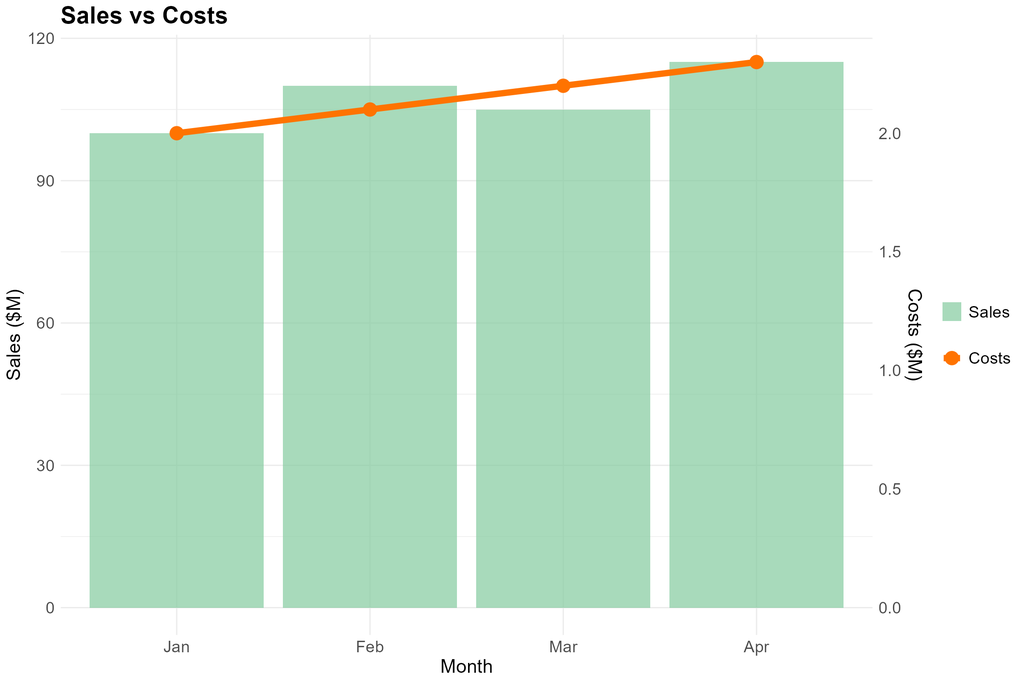

Problematic

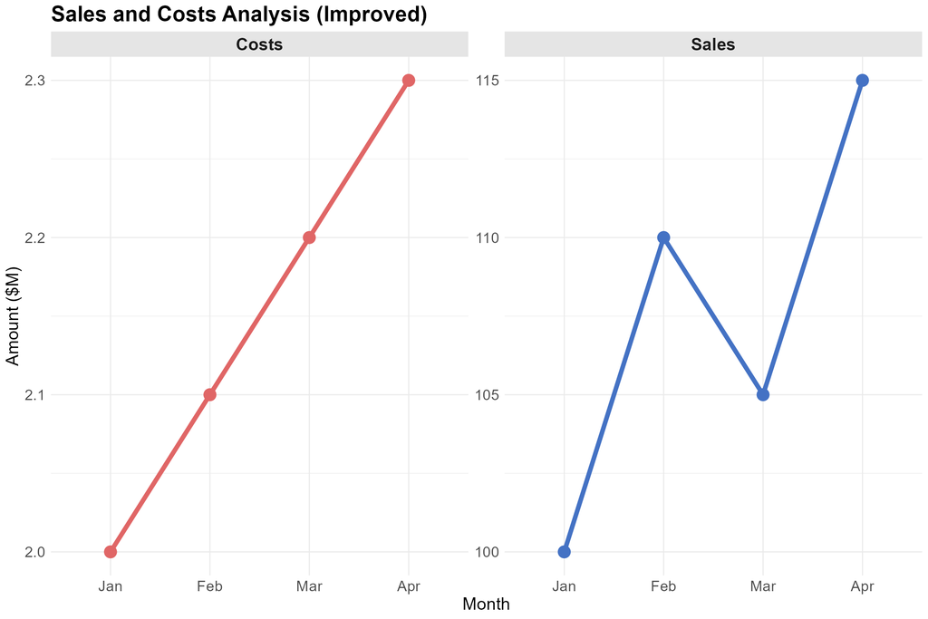

Improved

### Challenge 3: Sales & Costs

This chart compares sales revenue and costs over four months.

**❌ The Problem:**

Dual y-axes with vastly different scales (0-120 vs 0-2.4) create a misleading visual correlation. The costs line has been artificially scaled to match sales visually, obscuring the actual relationship.

**✓ The Solution:**

- Separate facets with independent scales
- Same chart type (line) for both metrics
- Actual values preserved and clearly labeled
- No misleading visual correlations

Now we can see each trend accurately without artificial scaling.

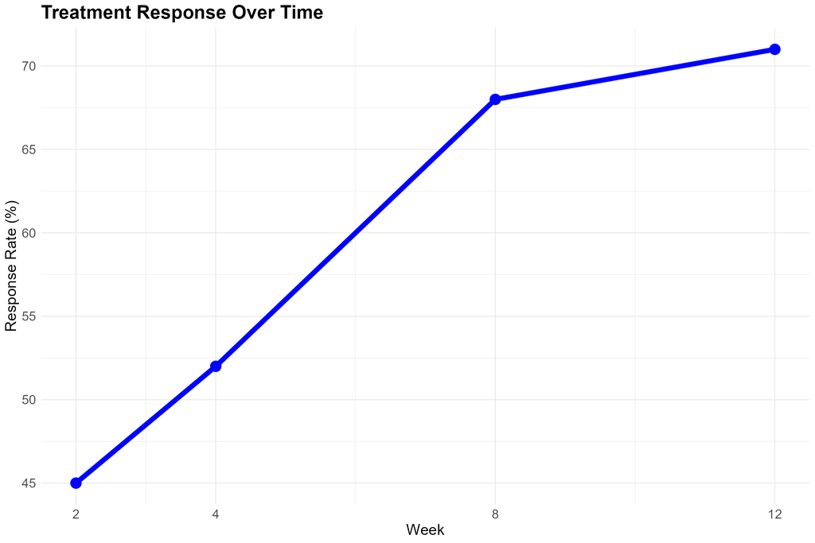

Problematic

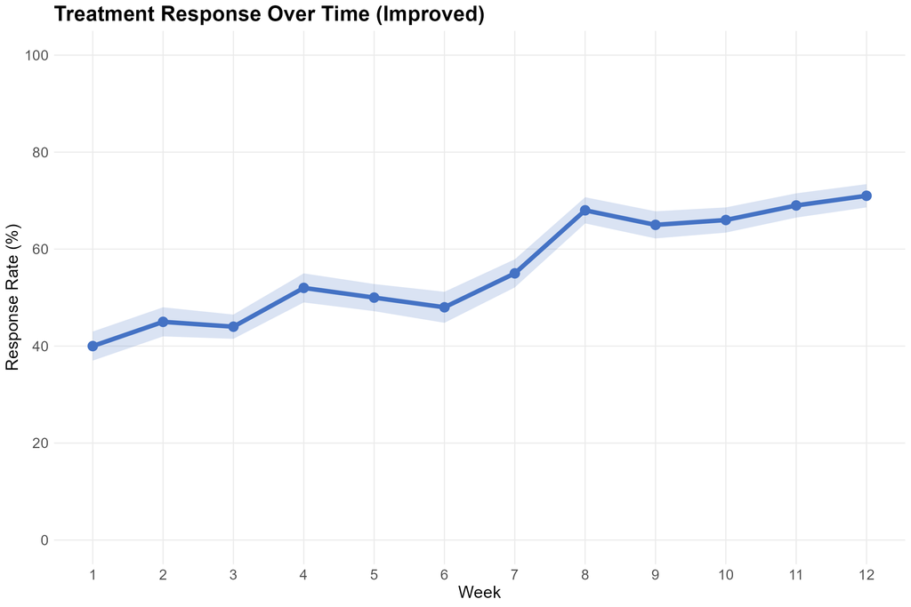

Improved

### Challenge 4: Treatment Response

This chart shows treatment response rates over a 12-week clinical trial.

The response appears to increase steadily and linearly. Is this the full story?

**❌ The Problem:**

Only 4 of 12 timepoints are shown (weeks 2, 4, 8, 12), cherry-picking data to create a false linear trend. Missing uncertainty estimates and intermediate measurements hide important variation.

**✓ The Solution:**

- All 12 weekly measurements shown
- Standard error bands indicate uncertainty
- Reveals actual trend with plateaus and fluctuations
- Y-axis starts at 0% for proper context

The complete data tells a more nuanced story with week-to-week variation.

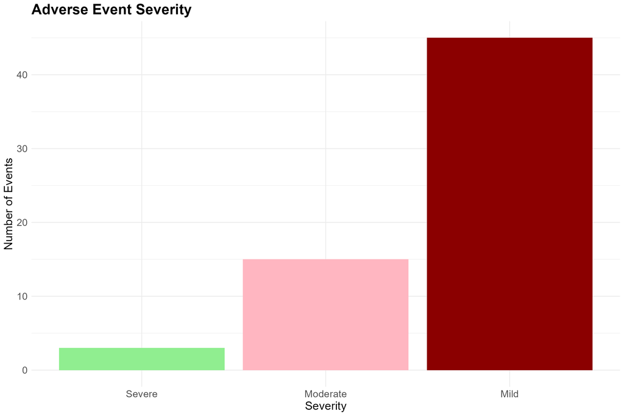

Problematic

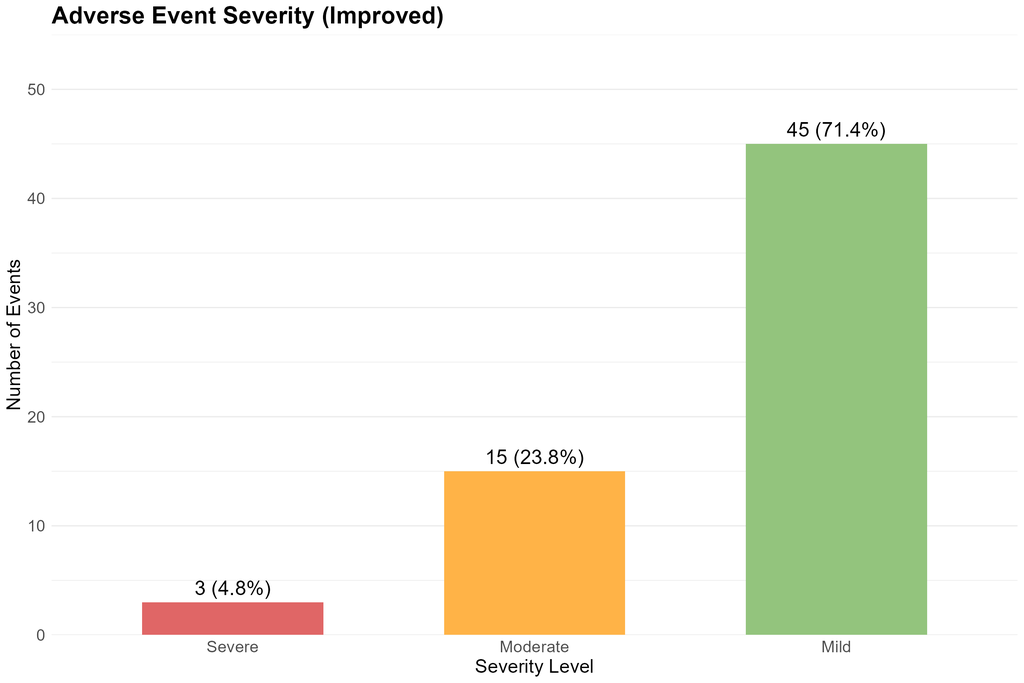

Improved

### Challenge 5: Event Severity

This chart shows adverse event severity distribution from a safety monitoring report.

Something looks... off. What jumps out at you?

**❌ The Problem:**

Colors are inverted! Severe events are shown in light green (associated with "safe"), while mild events are in dark red (associated with "danger"). This creates dangerous cognitive dissonance.

**✓ The Solution:**

Intuitive color coding aligns with universal safety conventions.

## Key Takeaways

These five challenges demonstrate common visualization pitfalls in pharmaceutical data presentation:

1. **Truncated Y-axis:** Always start bar charts at zero to avoid exaggerating differences
2. **Pie Charts:** Use bar charts for easier quantitative comparison; sort by frequency
3. **Dual Y-axes:** Avoid misleading correlations by using separate facets with independent scales
4. **Cherry-picked Data:** Show all available data points and include uncertainty measures
5. **Inappropriate Colors:** Use semantically meaningful colors aligned with severity/risk levels

**Remember:** Visualizations should inform, not mislead. Context and uncertainty are essential. Colors should support understanding, not confuse. Complete data presentation builds trust.